# Assignment 2

```r
library(tidyverse)
#Question 1
college_data <- read_csv("../Data_413/homework_2/collegedata.csv")
```

```r
#Question 2
nrow(college_data)
```

```
[1] 7175
```

```r
ncol(college_data)
```

```
[1] 12
```

```r
#Question 3
college_data %>%
  select(INSTNM, SAT_AVG, ADM_RATE)
```

```
# A tibble: 7,175 × 3
   INSTNM                              SAT_AVG ADM_RATE
   <chr>                                 <dbl>    <dbl>
 1 Alabama A & M University                849    0.874
 2 University of Alabama at Birmingham    1125    0.581
 3 Amridge University                       NA   NA
 4 University of Alabama in Huntsville    1257    0.763
 5 Alabama State University                825    0.459
 6 The University of Alabama              1202    0.526
 7 Central Alabama Community College        NA   NA
 8 Athens State University                  NA   NA
 9 Auburn University at Montgomery        1009    0.766
10 Auburn University                      1217    0.805
# ℹ 7,165 more rows
```

```r
#Question 4
drop_na(college_data)
```

```
# A tibble: 1,256 × 12
   UNITID  OPEID MN_EARN_WNE_P6 INSTNM SAT_AVG ADM_RATE  UGDS COSTT4_A AVGFACSAL
    <dbl>  <dbl> <chr>          <chr>    <dbl>    <dbl> <dbl>    <dbl>     <dbl>
 1 100654 100200 27800          Alaba…     849    0.874  4616    22667      7028
 2 100663 105200 37600          Unive…    1125    0.581 12047    22684     10517
 3 100706 105500 41300          Unive…    1257    0.763  6346    22059      9463
 4 100724 100500 23500          Alaba…     825    0.459  4704    19242      7952
 5 100751 105100 38500          The U…    1202    0.526 31663    28422      9802
 6 100830 831000 33200          Aubur…    1009    0.766  4171    19255      7251
 7 100858 100900 41700          Aubur…    1217    0.805 22095    29794      9945
 8 100937 101200 32400          Birmi…    1150    0.484  1289    48510      7233
 9 101189 100300 38100          Faulk…     972    0.454  2297    30557      5723
10 101435 101900 34000          Hunti…    1001    0.568  1140    34207      6615
# ℹ 1,246 more rows
# ℹ 3 more variables: GRAD_DEBT_MDN <chr>, AGE_ENTRY <chr>, ICLEVEL <dbl>
```

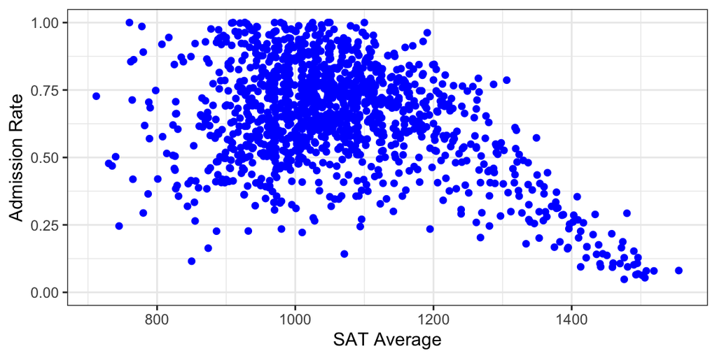

```r
college_data %>%
  ggplot(aes(x=SAT_AVG, y=ADM_RATE))+
  labs(x="SAT Average", y="Admission Rate")+
  geom_point(color="blue")
```

## Instructions

Complete the following exercises **using only the tidyverse packages** (e.g., `dplyr`, `tidyr`, `ggplot2`, `readr`, `stringr`, `forcats`, `lubridate`, `purrr`, etc.)

**Important:** This assignment is intended to assess your proficiency with the **tidyverse**. Solutions that use **base R** or **packages outside the tidyverse** to solve the problems will **not receive credit** unless explicitly permitted in the question.

1. Load the necessary **tidyverse** libraries.
2. Answer each question in a separate R code chunk.
3. Provide a detailed explanation of your approach for each solution.
4. Render your R Markdown document to an HTML file.
5. Submit the rendered HTML file to Canvas.

# Question:

- Task 1: Read data using a relative path
  - I set the working directory to my documents folder, and then my data was my homework_2 folder within my data_413 folder so I had to go down my folders in order to get to it

```r
Example:
college_data <- read_csv("../data/collegedata.csv")
```

- Task 2:Determine rows and columns
  - I printed the number of rows and columns inside of the data set using nrow and ncol
- Task 3: Use tidyverse to select INSTNM, SAT_AVG, and ADM_RATE
  - Use a pipe and the select function to select the three categories
- Task 4: Create a scatter plot for SAT_AVG and ADM_RATE (Remove NA)
  - Used ggplot to create a scatter plot of the two data points and removed NA

## Submission

- After completing **each question**, save your Quarto file, render it, then **stage and commit** your changes.
- Each commit should:
  - Represent **one logical change**.
  - Have a **short, descriptive** commit message.
  - Be written in the **present tense** (imperative mood).

  **Examples:**

  **Bad:** `Fix bug in the project` *Too vague—it does not explain which bug was fixed.*

  **Bad:** `Fixed crash on login screen when password is empty` *Uses the past tense.*

  **Good:** `Fix crash on login screen when password is empty`
- Include well-commented code and clear explanations for each solution.
- Make **at least one meaningful commit per question/part** (a minimum of **4 meaningful commits**).
- **Push your work to your** GitHub**. ane post the link on the text bar of the Canvas assignment.
- Assignments that are **not pushed to GitHub** will receive **no more than 60% of the available points**.
- Submit the rendered HTML file to **Canvas**. Assignments that are **not submitted to Canvas** will also receive **no more than 60% of the available points**.
- If you forget to submit your work to **GitHub** or **Canvas**, you have **up to three (3) days** after the due date to correct the submission. A **10% late penalty** will be applied to the assignment. **After three days, no submissions or corrections will be accepted.**
- **No corrections, re-submissions, or missing submissions will be accepted after the assignment has been graded**, including forgotten GitHub or Canvas submissions.

**Good luck!**